# TMS User Handbook

## 4.9 System

### Security & Roles

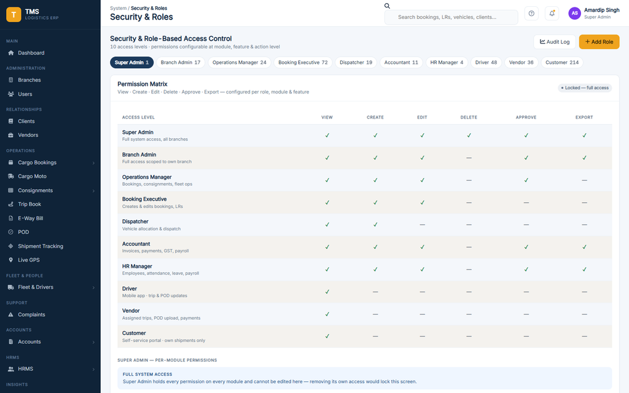

The permission matrix — ten access levels across six actions, per module.

The permission matrix. Ten access levels, six actions (view, create, edit, delete, approve, export), configurable per module. Pick a role from the chips to edit its per-module grid.

**Super Admin cannot be edited** — removing its own access would lock everyone out of this screen.

**Audit Log** shows who did what, and when.

### Settings

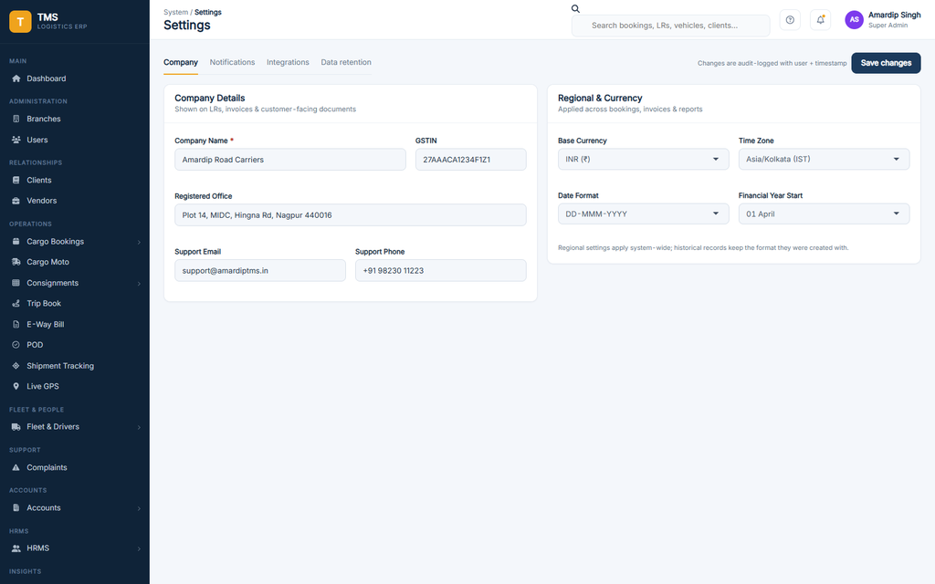

Settings: company details, notification routing, integrations and data retention.

Four tabs: company details (which appear on LRs and invoices), notification routing per event and channel, integrations, and data retention periods.

Financial records are fixed at eight years and cannot be shortened — statute, not preference.

> **On integrations:** every connector ships disconnected and **no credentials are stored in the application.** A real deployment supplies them as environment variables; this screen names them but never asks you to paste a key into a form.

# 5 Roles and what they can see

## 5.1 The ten access levels

| Role | What it is for | Screens | Can |
| --- | --- | --- | --- |
| Super Admin | Full system access, all branches | 28 | view, create, edit, delete, approve, export |
| Branch Admin | Full access scoped to own branch | 26 | view, create, edit, approve, export |
| Operations Manager | Bookings, consignments, fleet ops | 21 | view, create, edit, approve |
| Booking Executive | Creates & edits bookings, LRs | 18 | view, create, edit |
| Dispatcher | Vehicle allocation & dispatch | 18 | view, create |
| Accountant | Invoices, payments, GST, payroll | 22 | view, create, edit, approve, export |
| HR Manager | Employees, attendance, leave, payroll | 16 | view, create, edit, approve, export |
| Driver | Mobile app · trip & POD updates | 3 | view |
| Vendor | Assigned trips, POD upload, payments | 3 | view |
| Customer | Self-service portal · own shipments only | 2 | view |

Three of these — Driver, Vendor and Customer — are not internal staff logins. They are external parties reaching the system through a portal, and their numbers reflect how many drivers, vendors and customers exist rather than how many office accounts there are.

## 5.2 What a narrower role looks like

The navigation rail shows only what you can open. An accountant, for example, sees the money and the masters behind it, but not the dispatch board or the GPS feed:

[figure not shown]

And an external party sees almost nothing but their own dashboard:

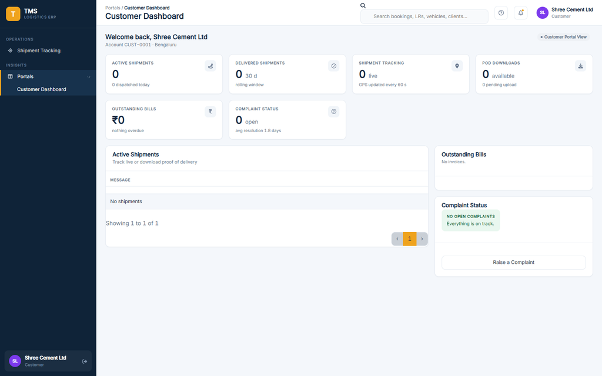

Signed in as a Customer.

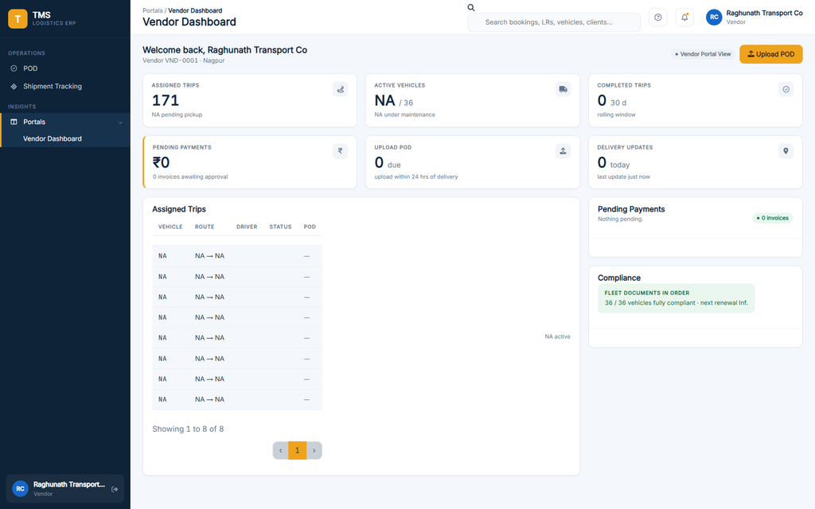

Signed in as a Vendor.

## 5.3 Branch scoping

Separately from your role, most users are **scoped to one branch**. Your lists, your dashboard cards and your charts all show your branch’s slice only.

This is applied to the data before it reaches the screen, so there is no view that leaks past it. If you genuinely need to see across branches, a Super Admin can grant **cross-branch access** on your user record.

# 6 Why did it say no?

Five things the system will refuse to do, and the reason for each. None of them is a bug.

**“Cannot invoice: this consignment has no verified POD.”** Billing for a delivery you cannot prove happened is how disputes start. Get the POD uploaded and verified first. The check is re-run at the moment you click, so a stale screen will not sneak one through.

**“Cannot allocate: load exceeds vehicle capacity.”** The booking is heavier than the truck’s rated capacity. Pick a bigger vehicle or split the load into multiple consignments.

**“Vehicle documents expired.”** Insurance, fitness, permit or PUC has lapsed. The vehicle is not legal on the road; renew it under **Fleet & Drivers → Vehicles** before allocating.

**“Licence expired”** / **“Licence expiring.”** Expired refuses the allocation. Expiring within 30 days warns but lets you proceed — treat it as a prompt to get the renewal moving.

**“Your role is not permitted to …”** The action is outside your permission set. This is checked on the server, so it holds regardless of what is on screen. Ask a Super Admin if you think your role is wrong.

# 7 Frequently asked

**Why is a number here different from the same number over there?** It should not be. Every figure is computed from the same underlying records rather than stored separately. If two screens genuinely disagree, that is worth reporting.

**Why does a card say “30 days” instead of “this month”?** Because a month-to-date figure is zero on the 1st, which reads as a broken feed. Rolling windows always have content. Genuinely monthly things — the payroll run, the deliveries-per-month chart — still use calendar months.

**I confirmed a booking. Why can’t dispatch see it?** Check it is *Confirmed* and not still *Draft*, and that it belongs to the branch the dispatcher is scoped to.

**A consignment shows two numbers. Which do I give the customer?** The **LR number**. That is what is printed on the lorry receipt they signed.

**The customer says they never got the POD.** Check the POD status on the consignment. If it is uploaded, they can download it themselves from the customer portal, or you can send a tracking link.

**Why is my driver marked “T” instead of present?** They were on a trip that day. Driver duty is derived from the Trip Book so nobody on the road is marked absent for not clocking in. It counts as a duty day for payroll.

**Nothing was actually emailed / no SMS went out.** Correct — the messaging gateways are not connected in this build. The app tells you when an action depends on one.

# 8 Glossary

| Term | Meaning |
| --- | --- |
| **Booking (BKG)** | A customer’s order to move a load. The start of the chain. |
| **Consignment (CN)** | The internal record of goods moving on one trip. |
| **LR — Lorry Receipt** | The document travelling with the goods, signed by the consignee. The number customers quote. |
| **Trip (TRP)** | One vehicle and driver moving between two points. Carries allowances and advances. |
| **POD — Proof of Delivery** | The signed confirmation that goods were received. Gates invoicing. |
| **E-way bill (EWB)** | GST document that must accompany goods above a value threshold. Distance-based validity; expires. |
| **GTA** | Goods Transport Agency — the GST classification for a road-freight carrier. |
| **RCM — Reverse Charge** | The recipient pays the GST, not the carrier. Carrier’s invoice shows zero tax. Standard for freight at 5%. |
| **FCM — Forward Charge** | The carrier collects the GST and remits it. 12% or 18%. |
| **GSP** | GST Suvidha Provider — the gateway through which e-way bills are filed. |
| **PUC** | Pollution Under Control certificate. One of four statutory vehicle documents. |
| **Fitness certificate** | Roadworthiness certification for a commercial vehicle. |
| **National permit** | Authorisation to run a goods vehicle across states. |
| **MXL / SXL** | Truck body types. MXL is the longer container body; both commonly 32 ft. |
| **Consolidation** | Several bookings sharing one vehicle down a common corridor. |
| **Split shipment** | One booking dropped at several delivery points, each with its own LR. |
| **Detention charge** | Billed when a vehicle is held at loading or unloading beyond free time. |
| **SLA** | Service level agreement — the deadline a complaint must be resolved within. |
| **Branch scoping** | Restriction of a user’s view to their own branch’s data. |
| **LWP** | Leave without pay. |
| **PF / ESI / PT** | Provident Fund, Employees’ State Insurance, Professional Tax — statutory payroll deductions. |

# 9 Appendix

## 9.1 What is in the demo data

| Records | Count |
| --- | --- |
| Branches | 18 |
| Internal users | 148 |
| Employees | 81 |
| Drivers | 48 |
| Vehicles | 62 |
| Customers | 214 |
| Vendors | 36 |
| Routes mapped | 291 |
| Bookings | 342 |
| Trips | 316 |
| Consignments | 316 |
| E-way bills | 30 |
| PODs | 267 |
| Invoices | 187 |
| Receipts | 95 |
| Complaints | 34 |

All of it is fictional. Names, GSTINs, PANs, bank accounts and phone numbers are generated from fixed patterns and belong to no real person or company.

## 9.2 Running the system yourself

Install dependencies, then start the app:

```bash
Rscript install_packages.R
```

```bash
Rscript -e "shiny::runApp('.', port = 8788, launch.browser = TRUE)"
```

Regenerate the demo data at any point — this resets everything to a clean state:

```bash
Rscript R/seed.R
```

Run the automated checks:

```bash
Rscript tests/smoke.R
```

Refresh the screenshots in this handbook after a UI change (with the app running):

```bash
cd tools && npm install && node capture-screenshots.js
```

Rebuild this handbook:

```bash
Rscript -e "rmarkdown::render('HANDBOOK.Rmd')"
```

## 9.3 Where to look next

- **README.md** — installation, architecture and project layout.
- **DESIGN-REVIEW.md** — the review of the original design deck, every ambiguity found in it, and the decision taken for each. Read this if you want to know *why* something works the way it does.

TMS · Transport Management System — generated 01 September 2026 at 14:13